# ¶ ¶

## Descriptor del promedio de la participación vs Departamento

Con ayuda del barplot podemos observar los departamentos que se encuentran por encima del promedio de la participación durante los 10 años(2011-2020) del estudio. Con esta información podríamos realizar algunas hipótesis más adelante.

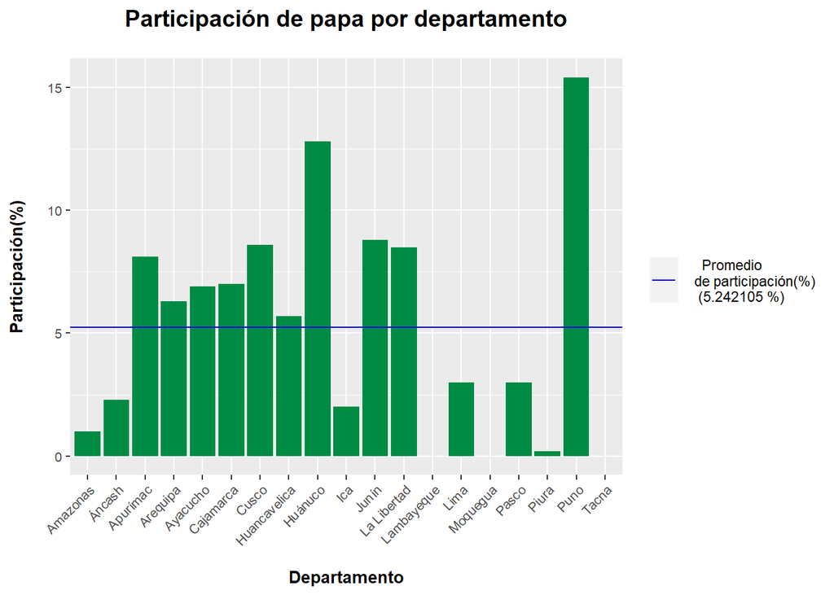

### **Entrega 2**

#### **Descriptores numéricos de las variables**

| Variable | Descriptores Numéricos |
| --- | --- |
| Participación | Máximo, Mínimo |
| Rendimiento Promedio | Máximo, Mínimo |
| Producción | Máximo, Mínimo |
| Superficie Cosechada | Máximo, Mínimo |

#### **Preguntas para determinar los descriptores numéricos**

##### **¿Qué región tiene mayor participación entre los años 2011 y 2020?**

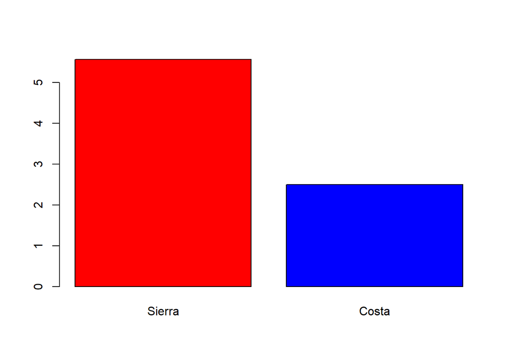

La región que cuenta con mayor producción de papa entre los años 2011 y 2020 es la Sierra.

##### **¿Qué departamento tiene mayor producción entre los años 2011 y 2020?**

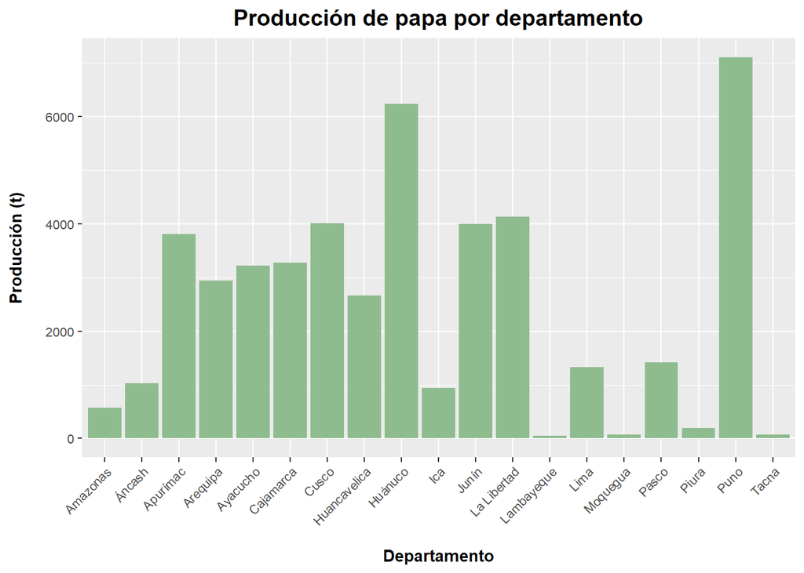

El departamento que tiene mayor producción entre los años 2011 y 2020 es Puno.

##### **¿Cuáles han sido los departamentos con mayor y menor rendimiento promedio entre los años 2011 y 2020?**

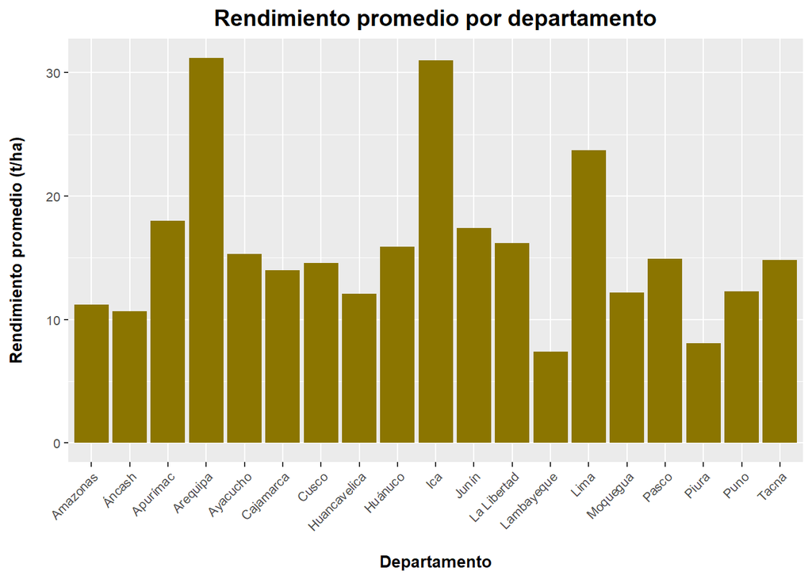

El Rendimiento Promedio máximo entre los Años 2011 y 2020 se da en el departamento de :

```
## # A tibble: 1 x 2
##   Departamento Rend.Max
##   <chr>           <dbl>
## 1 Arequipa         31.2
```

El Rendimiento Promedio mínimo entre los Años 2011 y 2020 se da en el departamento de :

```
## # A tibble: 1 x 2
##   Departamento Rend.Min
##   <chr>           <dbl>
## 1 Lambayeque        7.4
```

### Patrones

#### Patrón 1

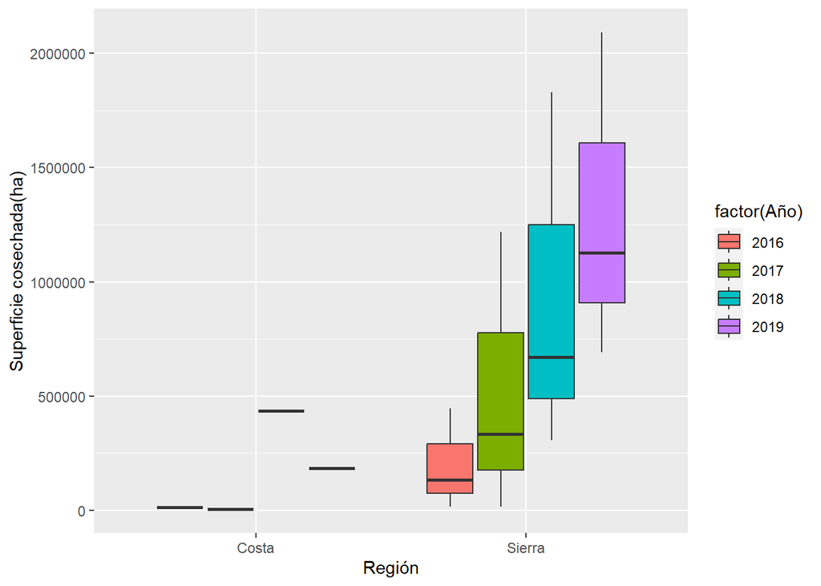

#### Patrón encontrado

Como podemos observar, para estos años (2016,2017,2018,2019) podemos ver que la superficie cosechada de papa cambia a medida que pasan los años. Respecto a la Costa vemos un comportamiento sinusoidal y respecto a la Sierra podemos ver que va aumentando por cada año. Los valores atípicos presentes se refieren a cada localización de la Sierra, es decir, existe una diferencia entre la superficie cosechada entre la Sierra Norte, Centro y Sur. Además, esta diferencia va aumentando con el paso de los años.

## Patrón 2

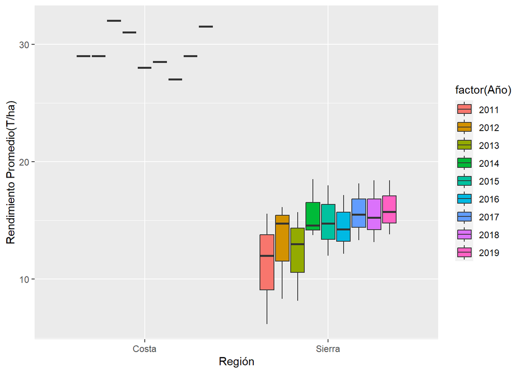

#### Patrón encontrado

Podemos concluir de la gráfica que, para estos años (2011 al 2019), la Costa presenta mayor rendimiento promedio que la Sierra. De igual forma, su comportamiento es sinusoidal. En relación a la Sierra, podemos observar que el rendimiento fue aumentando y además, el rendimiento de cada parte de la Sierra (Norte, Centro, Sur) se fue acercando conforme pasaron los años.

#### **Pregunta explorativa**

##### **¿Los departamentos con mayor producción de papa tienen mayor rendimiento promedio?**

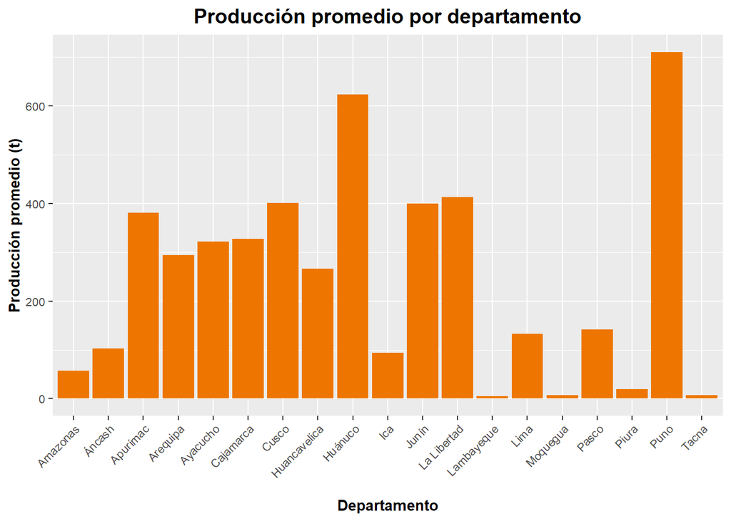

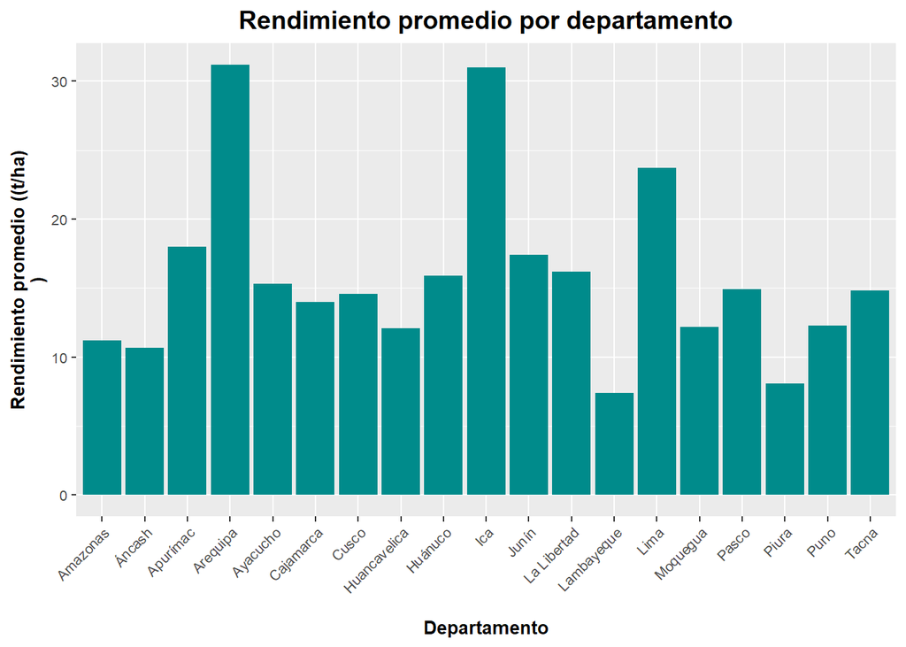

La condiciones del suelo de puno a pesar de ser un suelo fértil tienen condiciones meteorológicas complejas que no permiten que el suelo tenga un rendimiento alto en el departamento de Puno - En cambio en Arequipa la producción no es masiva por la cantidad reducida de terreno fértil que se tiene pero sus condiciones permiten una mejor tener un mejor suelo y por lo tanto un mejor rendimiento en sus suelos.

### **Entrega 3**

### **Análisis descriptivo**

#### **Descriptores**

Nivel de significancia: α -> 0.05  
x -> media del rendimiento promedio para la zona de Sierra  
desvest -> desviación estándar del rendimiento promedio para la zona de Sierra  
x2 -> media de la producción para los años “2017-2019” en la Sierra Sur  
desvest2 -> desviación estándar de la producción para los años “2017-2019” en la Sierra Sur  
x3 -> media de la participación para los años “2016-2019” en la Costa  
desvest3 -> desviación estándar de la participación para los años “2016-2019” en la Costa

#### **Para las pruebas**

##### **Para la prueba 1:**

| Año | Región | Rendimiento Promedio(T/ha) |
| --- | --- | --- |
| 2011 | Costa | 29.00000 |
| 2011 | Sierra | 11.41176 |
| 2012 | Costa | 29.00000 |
| 2012 | Sierra | 13.05882 |
| 2013 | Costa | 32.00000 |
| 2013 | Sierra | 12.41176 |
| 2014 | Costa | 31.00000 |
| 2014 | Sierra | 15.21176 |
| 2015 | Costa | 28.00000 |
| 2015 | Sierra | 15.11765 |
| 2016 | Costa | 28.50000 |
| 2016 | Sierra | 14.70588 |
| 2017 | Costa | 27.00000 |
| 2017 | Sierra | 15.82353 |
| 2018 | Costa | 29.00000 |
| 2018 | Sierra | 15.82353 |
| 2019 | Costa | 31.50000 |
| 2019 | Sierra | 16.17647 |
| 2020 | Costa | 8.50000 |
| 2020 | Sierra | 15.11765 |

###### **Gráfica**

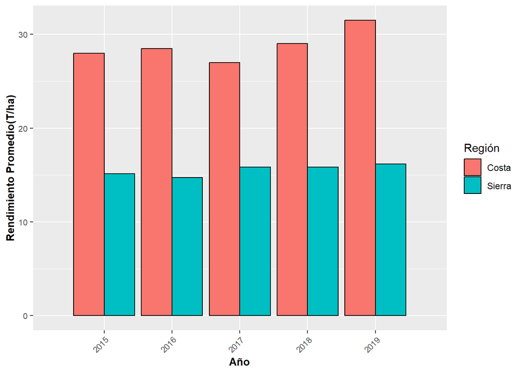

#### **Intervalos de confianza**

##### **Para la prueba 2:**

| Año | Región | Localización | Producción(t) |
| --- | --- | --- | --- |
| 2017 | Costa | Centro | 108.5000 |
| 2017 | Sierra | Centro | 368.0000 |
| 2017 | Sierra | Norte | 151.6667 |
| 2017 | Sierra | Sur | 315.0000 |
| 2018 | Costa | Centro | 120.5000 |
| 2018 | Sierra | Centro | 361.5000 |
| 2018 | Sierra | Norte | 172.0000 |
| 2018 | Sierra | Sur | 343.0000 |
| 2019 | Costa | Centro | 138.5000 |
| 2019 | Sierra | Centro | 403.0000 |
| 2019 | Sierra | Norte | 180.6667 |
| 2019 | Sierra | Sur | 345.1429 |

###### **Gráfica**

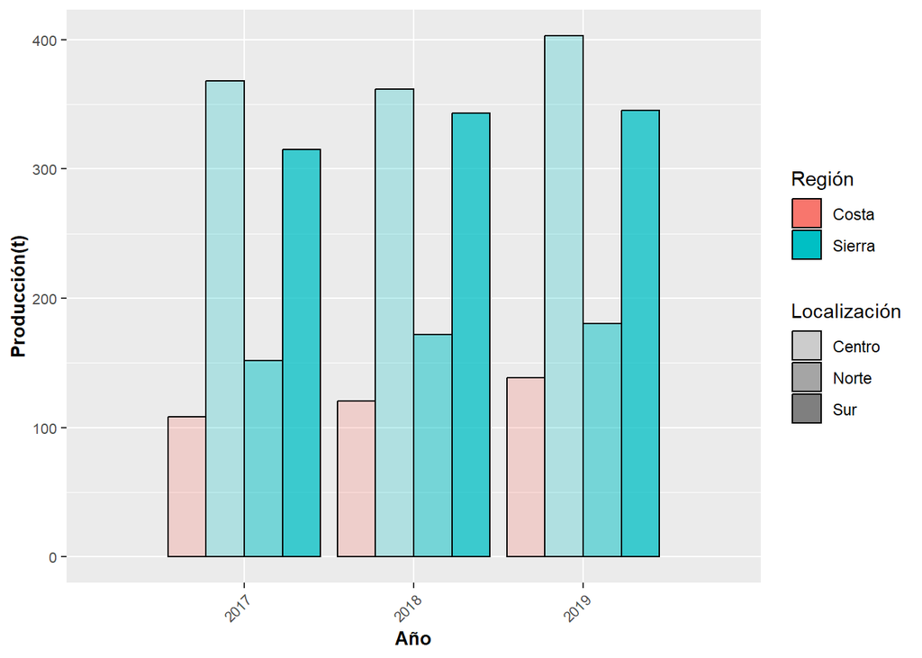

#### **Intervalos de confianza**

- Producción 2017 a 2019(Sierra Sur):
- [245.8888, 422.8731]

##### **Para la prueba 3:**

Se pudo observar que, para los años que analizamos (2016-2019), respecto a la participación, la región Costa fue de menor porcentaje

| Año | Región | Participación(%) |
| --- | --- | --- |
| 2016 | Costa | 2.000000 |
| 2016 | Sierra | 5.647059 |
| 2017 | Costa | 2.500000 |
| 2017 | Sierra | 5.647059 |
| 2018 | Costa | 2.000000 |
| 2018 | Sierra | 5.647059 |
| 2019 | Costa | 3.000000 |
| 2019 | Sierra | 5.470588 |

###### **Gráfica**

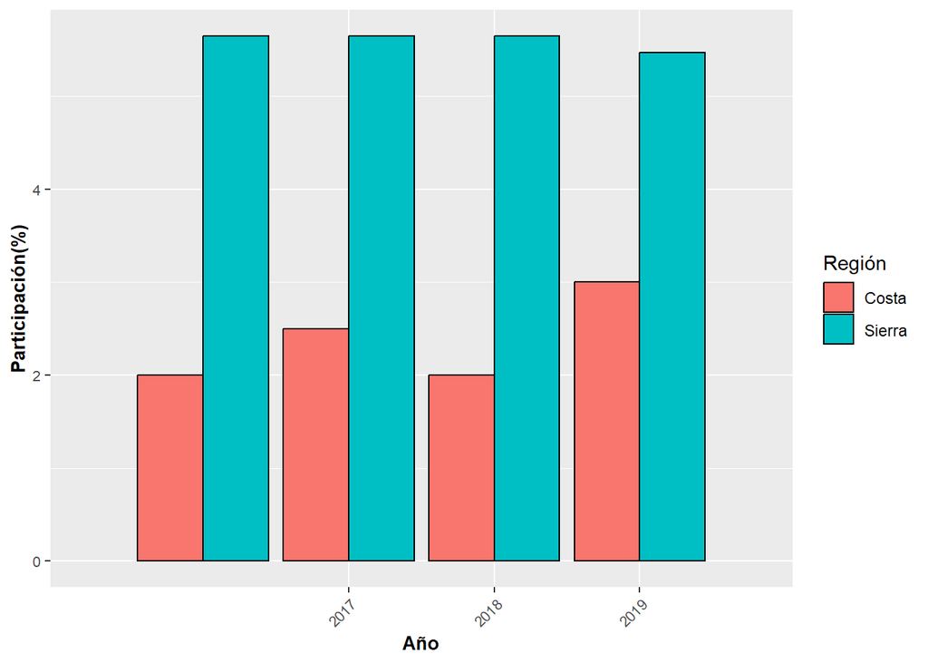

#### **Intervalos de confianza**

# Prueba 1

Según el Ministerio de Agricultura y Riego, el Rendimiento Promedio en el Perú es 14,5 t/ha.

¿En una zona andina el rendimiento promedio es mayor a 14,5 t/ha?

H0: μ ≤ 14.5  
H1: μ > 14.5

El estadístico de prueba fue hallado mediante distribución t-student, pues desconocemos la desviación estándar(poblacional). Después, se logró hallar los intervalos de confianza.

Se usó la siguiente fórmula para hallar el estadístico de prueba:

$$\frac{\bar{x}-\mu}{\frac{S}{\sqrt{n}}}$$

```
## [1] 1.598476
```

Usamos la siguiente fórmula para poder hallar el intervalo que se encuentra al lado izquierdo:

$$a = \bar{x} - t_{\alpha /2} \left (
\frac{S}{\sqrt{n}} \right )$$

```
## [1] 14.45832
```

Usamos la siguiente fórmula para poder hallar el intervalo que se encuentra al lado derecho:

$$b = \bar{x} + t_{\alpha /2} \left (
\frac{S}{\sqrt{n}} \right )$$

```
## [1] 16.6005
```

Comparamos la posición del estadístico de prueba respecto al área de rechazo:

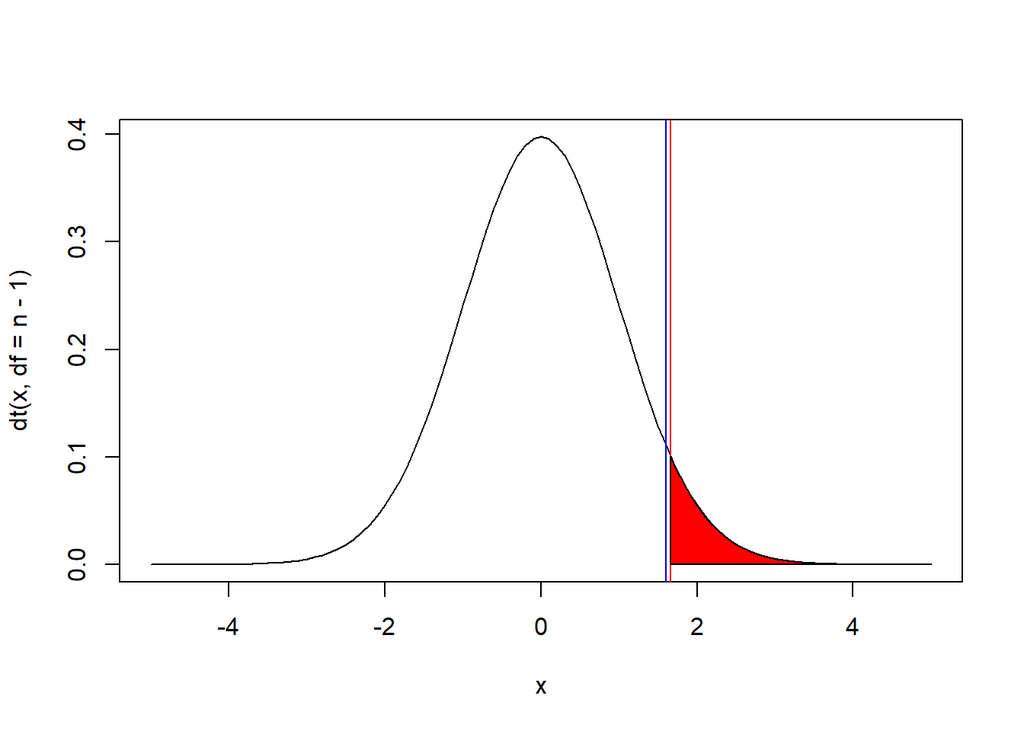

Se aprecia que el estadístico de prueba se encuentra fuera de la zona de rechazo. Esto significa que la hipótesis nula no es rechazada, lo que indica que nuestra hipótesis alternativa en una zona andina tiene un rendimiento promedio mayor a 14,5 t/ha, es rechazada.

Ahora realizaremos una prueba usando “t.test” para confirmar nuestros resultados.

```
##
##  One Sample t-test
##
## data:  PP2$`Rendimiento Promedio(T/ha)`
## t = 1.5985, df = 84, p-value = 0.05685
## alternative hypothesis: true mean is greater than 14.5
## 95 percent confidence interval:
##  14.45832      Inf
## sample estimates:
## mean of x
##  15.52941
```

El p-value es mayor al nivel de significancia establecido(0.05), lo cual indica que la Hipótesis Nula no se debe rechazar.

### Prueba 2

Tenemos el dato que la producción por departamento de la Sierra Sur en el 2016 es 304.64 toneladas.

¿El promedio de la producción de la sierra sur (Puno, Apurímac, Cusco, Arequipa, Ayacucho, Moquegua y Tacna), de cada uno de los siguientes tres años(2017,2018,2019) es mayor a 304.64 toneladas?

H0: μ ≤ 304.64  
H1: μ > 304.64

El estadístico de prueba fue hallado mediante distribución t-student, pues desconocemos la desviación estándar(poblacional). Después, se logró hallar los intervalos de confianza.

Se usó la siguiente fórmula para hallar el estadístico de prueba:

$$\frac{\bar{x}-\mu}{\frac{S}{\sqrt{n}}}$$

```
## [1] 0.5290561
```

Usamos la siguiente fórmula para poder hallar el intervalo que se encuentra al lado izquierdo:

$$a = \bar{x} - t_{\alpha /2} \left (
\frac{S}{\sqrt{n}} \right )$$

```
## [1] 237.4257
```

Usamos la siguiente fórmula para poder hallar el intervalo que se encuentra al lado derecho:

$$b = \bar{x} + t_{\alpha /2} \left (
\frac{S}{\sqrt{n}} \right )$$

```
## [1] 431.3362
```

Comparamos la posición del estadístico de prueba respecto al área de rechazo:

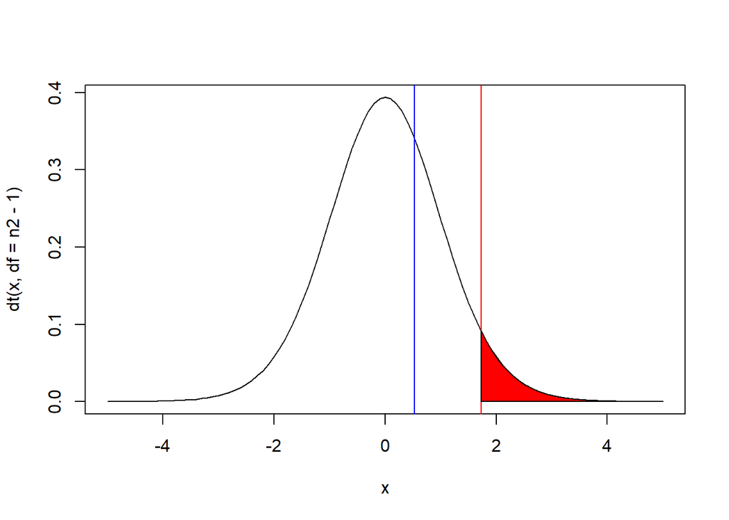

Ahora realizaremos una prueba usando “t.test” para confirmar nuestros resultados.

```
##
##  One Sample t-test
##
## data:  PP3$`Producción(t)`
## t = 0.52906, df = 20, p-value = 0.3013
## alternative hypothesis: true mean is greater than 304.64
## 95 percent confidence interval:
##  237.4257      Inf
## sample estimates:
## mean of x
##   334.381
```

El p-value es mayor al nivel de significancia establecido(0.05), lo cual indica que la Hipótesis Nula no se debe rechazar.

### Prueba 3

Tenemos el dato que la participación de la Costa en el 2015 es de 4.1%.

¿La participación de la Costa, de cada uno de los siguientes todos los años es menor 4.1%?

H0: μ ≥ 4.1  
H1: μ < 4.1

El estadístico de prueba fue hallado mediante distribución t-student, pues desconocemos la desviación estándar (poblacional). Después se logro hallar los intervalos de confianza.

Se usó la siguiente fórmula para hallar el estadístico de prueba:
$$\frac{\bar{x}-\mu}{\frac{S}{\sqrt{n}}}$$

[output not shown]

Usamos la siguiente fórmula para poder hallar el intervalo que se encuentra al lado izquierdo:

$$a = \bar{x} - t_{\alpha /2} \left (
\frac{S}{\sqrt{n}} \right )$$

```
## [1] 1.557236
```

Usamos la siguiente fórmula para poder hallar el intervalo que se encuentra al lado derecho:

$$b = \bar{x} + t_{\alpha /2} \left (
\frac{S}{\sqrt{n}} \right )$$

```
## [1] 3.442764
```

Realizaremos una prueba de hipótesis para comprobar si la hipótesis nula (H0) se rechaza o no. Esta prueba es de 1 sola cola, la cual se dirige hacia la izquierda. Esta cola nos definirá nuestra área de rechazo.

Comparamos la posición del estadístico de prueba respecto al área de rechazo:

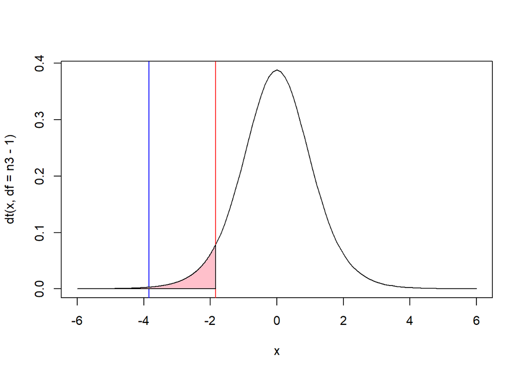

Ahora realizaremos una prueba usando “t.test” para confirmar nuestros resultados.

```
##
##  One Sample t-test
##
## data:  PP4$`Participación(%)`
## t = -5.4294, df = 19, p-value = 1.537e-05
## alternative hypothesis: true mean is less than 4.1
## 95 percent confidence interval:
##      -Inf 3.009558
## sample estimates:
## mean of x
##       2.5
```

Observamos que el p-value es menor al nivel de significancia (0.05), y con esto comprobamos que la Hipótesis Nula se debe rechazar.

### Regresión

Finalmente, nuestro equipo busco encontrar alguna relación entre 2 variables que sea lo más significativa posible. Esto lo conseguimos haciendo uso del coeficiente de correlación y del concepto de regresión lineal. Luego una serie de pruebas con todas nuestras variables cuantitativas, encontramos ciertas dependencias entre nuestras variables de estudio que, si bien se observaron que son muy bajas, valdrán la pena observar el análisis que se les realizó.Pero antes, observaremos como se construye una ecuación de regresión lineal:  
Y= α + βx  
Donde: -Y: Es un valor estimado de la variable “y”  
-x: es la variable independiente  
-α: es el valor estimado de “y” cuando x es igual a cero  
-β: es el valor de la pendiente de la recta

1-El primer modelo:

#### **¿Un mayor rendimiento promedio hace posible que se obtenga una mayor producción de las cosechas de papa?**

Con ayuda de la regresión lineal hallaremos si las variables de rendimiento promedio y producción tienen una relación.

Como primer paso hallaremos el coeficiente de correlación

```
## [1] 0.1416363
```

Se observa que el coeficiente de correlación es positivo, más específicamente es un coeficiente de correlación débil positivo al ser mayor a 0 y menor a 0,5. Con este dato se puede determinar que existe alguna relación entre variables. COntinuamos hallando el coeficiente de determinación

```
## [1] 0.02006084
```

El coeficiente de determinación hallado nos señala que aproximadamente el 2% de la variación de la producción esta representado por la variación del rendimiento promedio. Hallamos los valores de los parámetros “β” y “b”.

```
## [1] 3.771092
```

```
## [1] 187.8133
```

```
## (Intercept)          B2
##  187.813267    3.771092
```

Con los parámetros anteriores ya calculados, tenemos que nuestra ecuación de regresión lineal es: Y = 187.8133 + 3.771092x

Esta ecuación de regresión lineal nos dará valores estimados para nuestra variable dependiente, cuyo error de estimación estándar será:

```
## [1] 210.1458
```

Usamos la función Summary para comparar los valores determinados en pasos anteriores:

```r
summary(lm(A2~B2))
```

```
##
## Call:
## lm(formula = A2 ~ B2)
##
## Residuals:
##     Min      1Q  Median      3Q     Max
## -252.46 -192.85  -36.87  146.85  598.39
##
## Coefficients:
##             Estimate Std. Error t value Pr(>|t|)
## (Intercept)  187.813     34.052   5.515 1.14e-07 ***
## B2             3.771      1.922   1.962   0.0513 .
## ---
## Signif. codes:  0 '***' 0.001 '**' 0.01 '*' 0.05 '.' 0.1 ' ' 1
##
## Residual standard error: 210.1 on 188 degrees of freedom
## Multiple R-squared:  0.02006,    Adjusted R-squared:  0.01485
## F-statistic: 3.849 on 1 and 188 DF,  p-value: 0.05126
```

Con respecto a la función Summary identificamos valores importantes que nos facilitaría determinar algunas incógnitas (la intercepción, la pendiente, el p-value, el coeficiente de determinación y el error residual junto a sus grados de libertad) sin necesidad de realizar todos los pasos anteriores.  
Intercepción = 187.813  
Pendiente = 3.771  
p-value = 0.05126  
Coeficiente de determinación = 0.02006  
Error residual = 210.1 grados de libertad 188  
Cuando tengamos estas incognitas que son brindadas por la función Summary podemos hallar otras variables como el coeficiente de correlación, que nos decía si era una regresión positiva/negativa fuerte/débil, este coeficiente puede ser hallado sacando la raíz cuadrada del coeficiente de determinación, la ecuación lineal de dicha regresión que esta formada por la intercepción y la pendiente antes hallada y podríamos determinar si rechazamos alguna hipótesis de regresión si el p-value es menor al nivel de significancia y si el p-value es mayor al nivel de significancia no se rechazaría dicha hipótesis.

La gráfica de la regresión lineal entre ambas variables es la siguiente:

[figure not shown]

Observamos que el coeficiente de correlación es muy debil, es por eso que relacionar la producción y el rendimiento promedio no sea tan buena idea. También observamos que nuestro coeficiente de determinación es bajo, esto quiere decir que nuestro modelo lineal que relaciona a la producción con el rendimiento tendría muy poca asertividad si queremos predecir un valor fuera del rango de los datos.

*Filtramos los datos para separar las 2 variables.

```
##  [1] 213 170 145 222  77 107  88 123 143  38
```

```
##  [1] 2011 2012 2013 2014 2015 2016 2017 2018 2019 2020
```

```
##  [1] 590 568 644 669 722 692 743 798 839 839
```

a)Como primer paso hallaremos el coeficiente de correlación entre los años y la producción del departamento de Puno:

```
## [1] 0.9734138
```

Se observa que el coeficiente de correlación es de tipo fuerte positivo, porque es mayor a cero y mayor a 0.5. Con este dato se puede determinar que existe alguna relación entre variables. Continuamos hallando el coeficiente de determinación:

```
## [1] 0.9475344
```

El coeficiente de determinación hallado nos señala que aproximadamente el 94% de la variación de la producción esta representado por la variación de los años. Hallamos los valores de los parámetros “β” y “b”

Hallamos los valores de los parámetros “α” y “β”. Primero hallamos el valor de β, el cuál se calcula de la siguiente manera:

```
## [1] 30.90909
```

Una vez que hallamos el valor de β, este nos ayudará a calcular el valor de α de la siguiente manera:

```
## [1] -61586.87
```

```
##  (Intercept)            E
## -61586.87273     30.90909
```

Con los parámetros anteriores ya calculados, tenemos que nuestra ecuación de regresión lineal es:  
Y = -61586.87 + 30.90909x

Esta ecuación de regresión lineal nos dará valores estimados para nuestra variable dependiente, cuyo error de estimación estándar será:

```
## [1] 23.35653
```

Usamos la función Summary para comparar los valores determinados en pasos anteriores:

```r
summary(lm(D~E))
```

```
##
## Call:
## lm(formula = D ~ E)
##
## Residuals:
##     Min      1Q  Median      3Q     Max
## -34.218 -12.945   7.645  16.736  27.055
##
## Coefficients:
##               Estimate Std. Error t value Pr(>|t|)
## (Intercept) -61586.873   5182.801  -11.88 2.31e-06 ***
## E               30.909      2.571   12.02 2.12e-06 ***
## ---
## Signif. codes:  0 '***' 0.001 '**' 0.01 '*' 0.05 '.' 0.1 ' ' 1
##
## Residual standard error: 23.36 on 8 degrees of freedom
## Multiple R-squared:  0.9475, Adjusted R-squared:  0.941
## F-statistic: 144.5 on 1 and 8 DF,  p-value: 2.117e-06
```

Con respecto a la función Summary identificamos valores importantes que nos facilitaría determinar algunas incógnitas (la intercepción, la pendiente, el p-value, el coeficiente de determinación y el error residual junto a sus grados de libertad) sin necesidad de realizar todos los pasos anteriores.  
Intercepción = -61586.873  
Pendiente = 30.909  
p-value = 2.117e-06  
Coeficiente de determinación = 0.9475  
Error residual = 23.36 grados de libertad 8  
Cuando tengamos estas incognitas que son brindadas por la función Summary podemos hallar otras variables como el coeficiente de correlación, que nos decía si era una regresión positiva/negativa fuerte/débil, este coeficiente puede ser hallado sacando la raíz cuadrada del coeficiente de determinación, la ecuación lineal de dicha regresión que esta formada por la intercepción y la pendiente antes hallada y podríamos determinar si rechazamos alguna hipótesis de regresión si el p-value es menor al nivel de significancia y si el p-value es mayor al nivel de significancia no se rechazaría dicha hipótesis.

La gráfica de la regresión lineal entre ambas variables es la siguiente:

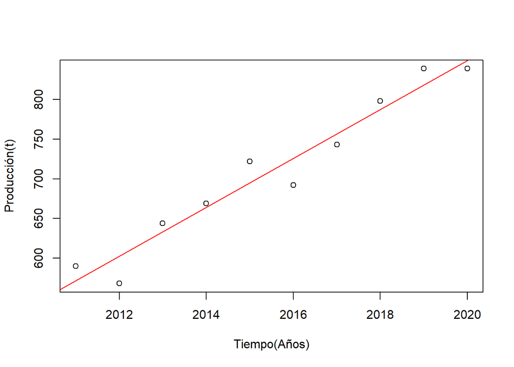

Observamos que el coeficiente de correlación es muy fuerte, es por eso que la producción y el tiempo si tienen una buena relación. Además, al ser presentar una correlación positiva se puede observar se da una relación directamente proporcional entre las variables. También observamos que nuestro coeficiente de determinación es alto, esto quiere decir que nuestro modelo lineal que relaciona a la producción con el tiempo en el departamento de Puno tendría una buena asertividad si queremos predecir un valor fuera del rango de los datos.

b)Como Segunda instancia hallamos el coeficiente de correlación entre los años y la producción del departamento de Lima:

```
## [1] -0.7034171
```

```
## [1] 0.4947956
```

Hallamos los valores de los parámetros “α” y “β”. Primero hallamos el valor de β, el cuál se calcula de la siguiente manera:

```
## [1] -13.61212
```

Una vez que hallamos el valor de β, este nos ayudará a calcular el valor de α de la siguiente manera:

```
## [1] 27567.83
```

Con los parámetros anteriores ya calculados, tenemos que nuestra ecuación de regresión lineal es:  
Y = 27567.83 -13.61212x

Esta ecuación de regresión lineal nos dará valores estimados para nuestra variable dependiente, cuyo error de estimación estándar será:

```
## [1] 44.17011
```

Usamos la función Summary para comparar los valores determinados en pasos anteriores:

```r
summary(lm(C~E))
```

```
##
## Call:
## lm(formula = C ~ E)
##
## Residuals:
##    Min     1Q Median     3Q    Max
## -62.41 -23.54 -14.52  23.11  68.98
##
## Coefficients:
##              Estimate Std. Error t value Pr(>|t|)
## (Intercept) 27567.830   9801.324   2.813   0.0227 *
## E             -13.612      4.863  -2.799   0.0232 *
## ---
## Signif. codes:  0 '***' 0.001 '**' 0.01 '*' 0.05 '.' 0.1 ' ' 1
##
## Residual standard error: 44.17 on 8 degrees of freedom
## Multiple R-squared:  0.4948, Adjusted R-squared:  0.4316
## F-statistic: 7.835 on 1 and 8 DF,  p-value: 0.02323
```

Con respecto a la función Summary identificamos valores importantes que nos facilitaría determinar algunas incógnitas (la intercepción, la pendiente, el p-value, el coeficiente de determinación y el error residual junto a sus grados de libertad) sin necesidad de realizar todos los pasos anteriores.  
Intercepción = 27567.830  
Pendiente = -13.612  
p-value = 0.02323  
Coeficiente de determinación = 0.4948  
Error residual = 44.17 grados de libertad 8  
Cuando tengamos estas incognitas que son brindadas por la función Summary podemos hallar otras variables como el coeficiente de correlación, que nos decía si era una regresión positiva/negativa fuerte/débil, este coeficiente puede ser hallado sacando la raíz cuadrada del coeficiente de determinación, la ecuación lineal de dicha regresión que esta formada por la intercepción y la pendiente antes hallada y podríamos determinar si rechazamos alguna hipótesis de regresión si el p-value es menor al nivel de significancia y si el p-value es mayor al nivel de significancia no se rechazaría dicha hipótesis.

La gráfica de la regresión lineal entre ambas variables es la siguiente:

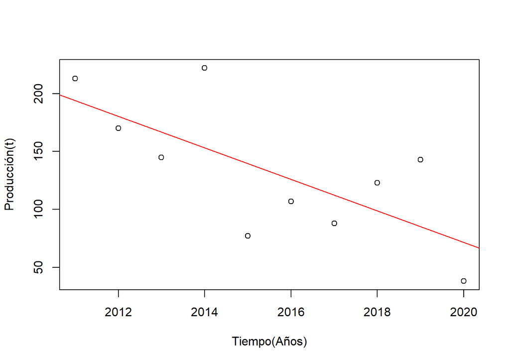

Observamos que el coeficiente de correlación es fuerte, es por eso que la producción y el tiempo si tienen una buena relación. Además, al ser presentar una correlación negativa se puede observar se da una relación inversamente proporcional entre las variables. También observamos que nuestro coeficiente de determinación es bajo, esto quiere decir que nuestro modelo lineal que relaciona a la producción con el tiempo en el departamento de Lima tendría una mala asertividad si queremos predecir un valor fuera del rango de los datos.

### **Bibliografía**

- Ministerio de Agricultura y riego. (2018). Análisis de Mercado. 2020, de Ministerio de Agricultura y riesgo. Sitio web: https://cdn.www.gob.pe/uploads/document/file/1471847/An%C3%A1lisis%20de%20Mercado%20-%20Papa%202020.pdf
- Instituto de Investigación y Desarrollo de Comercio Exterior de la Cámara de Comercio de Lima. (2018). Papa, milenario producto andino. Sitio web: https://www.camaralima.org.pe/wp-content/uploads/2020/06/Papa-milenario-producto-andino-1.pdf +Ministerio de Agricultura y riego. (s.f.). Perfil Productivo y Competitivo de los principales cultivos del sector. Sitio web: https://app.powerbi.com/view?r=eyJrIjoiMDNmYzU1Y2ItM2I1Ny00Y2E5LWEzOGMtM2Y4Y2VmNmZiNWQzIiwidCI6IjNmMmVjNzcwLWMxYjEtNDEzYy05ZmY5LTRjOWY3MDA1OWYxOCJ9